# El cuadrado latino

2/4/2021

## Introducción

## Historia y cualidades

1. Desarrollado para:

   1.1. Controlar efecto de condiciones ajenas al experimento

   1.2. Combinar varios factores
2. Arreglo en filas y columnas de factores experimentales

   2.1. Cada factor aparece 1 vez por fila y columna

   2.2. Factor con \(N\) niveles \(\rightarrow\) cuadro \(N \times N\)

## Diseño clásico

1. Control de efectos ajenos

   1.1. 1 Factor experimental con 3 niveles:

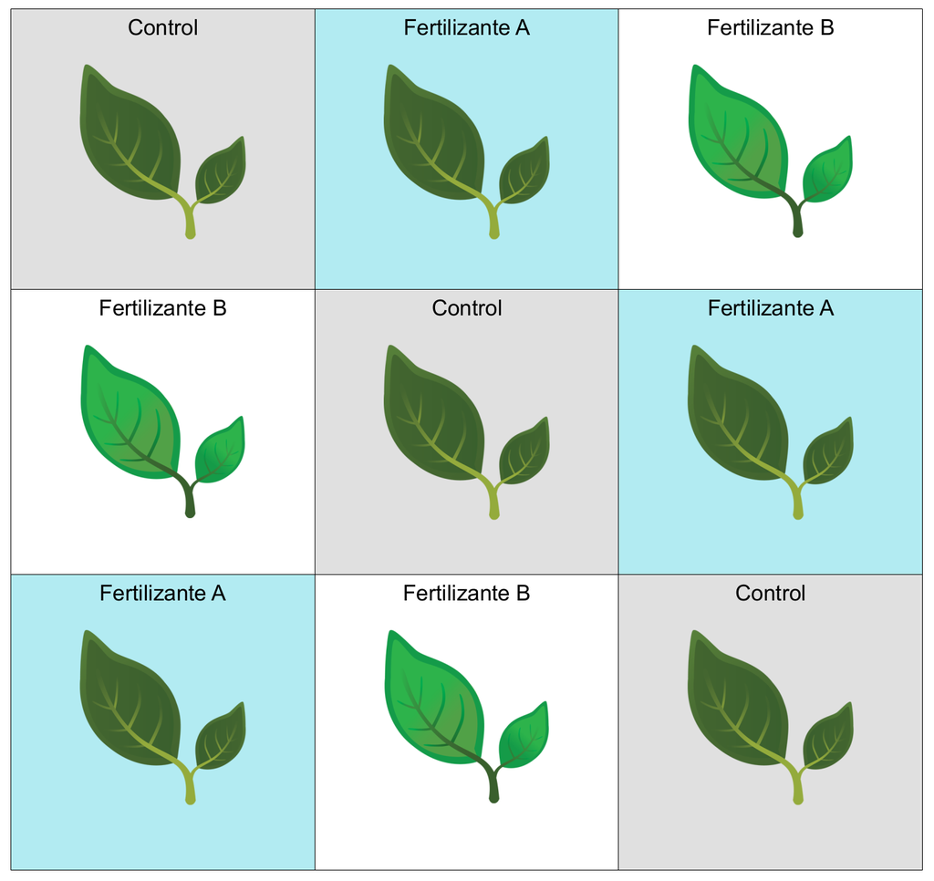

## Diseño alternativo –cuadrado greco-latino

- Combinación de dos factores

\[ \mathrm{Factor\ A} = \{a, b, c \} \] \[ \mathrm{Factor\ B} = \{\alpha, \beta, \gamma \}\]

| \(a, \alpha\) | \(b, \beta\) | \(c, \gamma\) |
| --- | --- | --- |
| \(c, \beta\) | \(a, \gamma\) | \(b, \alpha\) |
| \(b, \gamma\) | \(c, \alpha\) | \(a, \beta\) |

## Sobre el cuadrado greco-latino

1. Sólo para estudios simétricos (factores con mismo número de niveles)

   1.1. Cuadrados superpuestos
2. Cada combinación aparece 1 vez
3. Estadísticamente:

   3.1. Sólo se estiman efectos aditivos (no hay grados de libertad para interacciones)

   3.2. Se necesitan más cuadrados para estimar interacciones

   ```
        3.2.1. Deben ser aleatorizados
   ```

## Consideraciones generales de CL’s

## Logísticas

1. Complejidad crece a ritmo \(N^2\)
2. Pocos tratamientos = Pocos grados de libertad
3. Se recomienda:

   3.1. \(4 \geq N \leq 8\)
4. Si interacciones biológicas son posibles \(\rightarrow\) **EVITAR**

## Biológicas

- Cualidades heterogéneas del suelo

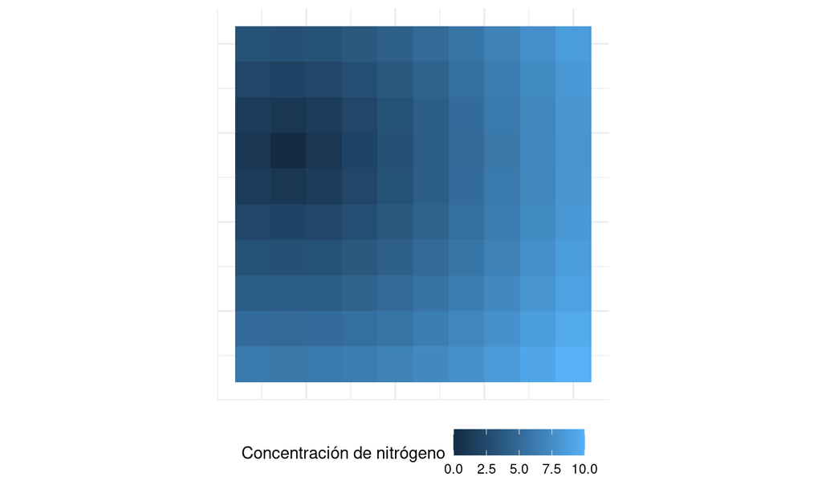

Ejemplo de gradiente espacial

## Biológicas

- Efecto de borde

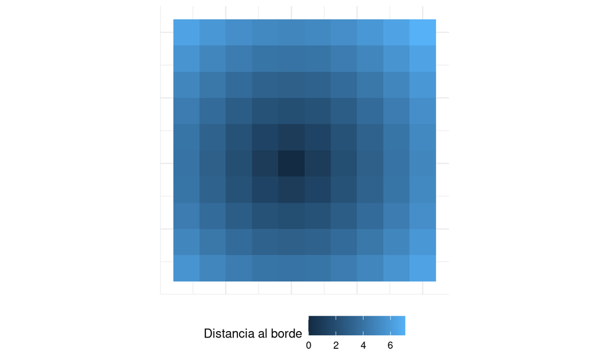

Efecto de borde

## Ventajas

1. Cuando \(N\) tratamientos es manejable es un diseño robusto
2. Pueden existir réplicas –cuadrado latino extendido

   2.1. Réplicas suficientes \(\rightarrow\) estimación de interacciones
3. Puede ser aleatorizado

## Análisis de diseños en cuadrado latino

## Un sólo cuadrado

1. Cada *bloque* es una réplica
2. \(N\) tratamientos = \(N\) réplicas
3. Para análisis de 1 sólo factor en **R**:

```r
aov(y ~ x, datos)
lm(y ~ x, datos)
```

1. De dos factores (efectos aditivos únicamente) –cuadrado greco-latino:

```r
aov(y ~ x1 + x2, datos)
lm(y ~ x1 + x2, datos)
```

Donde el número de tratamientos de \(x_1\) es el mismo que de \(x_2\)

## CLs extendidos

1. Cada cuadrado aleatorizado = bloque
2. Todos los tratamientos están contenidos en cada bloque
3. Factor de agrupamiento es el bloque

   3.1. Efecto aleatorio por bloque

   3.2. Bloques necesarios para interacciones = Tratamientos + 1
4. El análisis:

```r
aov(y = x1 * x2 + Error(bloque/(x1*x2)), datos)
```

## Modelos alternativos

1. Frecuentemente en diseños CL se considera que

   1.1. Hay dos factores de agrupación –filas y columnas 1.2. Es posible modelarlos con efectos aleatorios

```r
library(lme4)
lmer(y ~ x1 + x2 + (1|filas) + (1|columnas), datos)
```

El modelo es aditivo porque no podemos ajustar la interacción \(x_1 : x_2\)

## Consideraciones

- Si no hay un gradiente identificado que tomar en cuenta \(\rightarrow\) **EVITAR CL**
- Identificar el gradiente puede incluso ayudar a incluir en análisis y aislar varianza que explica dicho gradiente (modelo ANCOVA en Unidad 5)

Regresar al índice del curso